# R_Junkies Group Project

## R_Junkies

### Group members:

- Yağmur Ulutürk Tekten
- Cem Gürkan
- Rezan Azizoğlu
- Semih Tekten

Big Data Analytics  
BDA 503, 2017  
Berk Orbay

## Dataset: Airplane Crashes

### from 1908 to 2017

After collecting & preprocessing the dataset contains:  
**17** variables  
**5.543** observations

Airplane Crashes Since 1908 - Kaggle  
Air transport, passengers carried (1970-2016) - World Bank  
Air transport, registered carrier departures worldwide (1970-2016) - World Bank  
Airplane Crashes Since 2009 - Plane Crash Info

- Crashes after 2009 were crawled from PlaneCrashInfo.com, using Python.

## Objectives

- Understanding statistics and characteristics of past airplane crashes
- Visualizing results of exploratory analysis
- Demonstrating geolocations of airplane crashes on a static map
- Developing and demonstrating R & RMarkdown skills of R_Junkies

## Questions

- How many passengers died in airplane crashes since 1908?
- Which airplanes have most records of crashes so far?
- How many accidents occured, compared to number of departures over years?
- Which civil operators have the most records of accidents and fatalities?
- What is the crash history of Turkish Airlines?
- Have airplane flights gotten more secure over time?
- Has survival rate of a single airplane crash increased over time?
- What are the causes of airplane crashes?
- In which countries the most airplane accidents occured?

## Total Fatalities Over Years

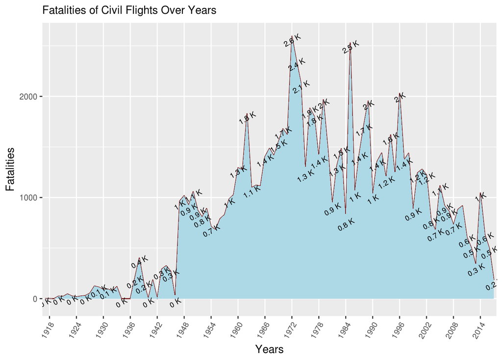

## Top 10 Airplane Types & Crashes

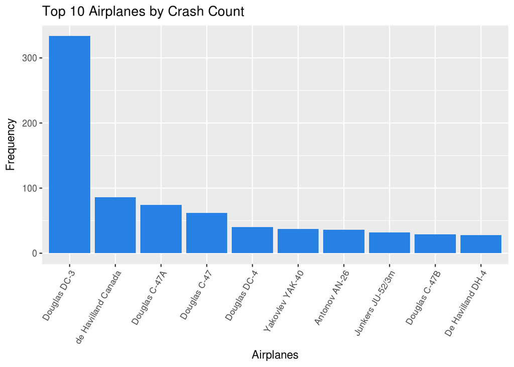

## Comparing Accidents & Departures

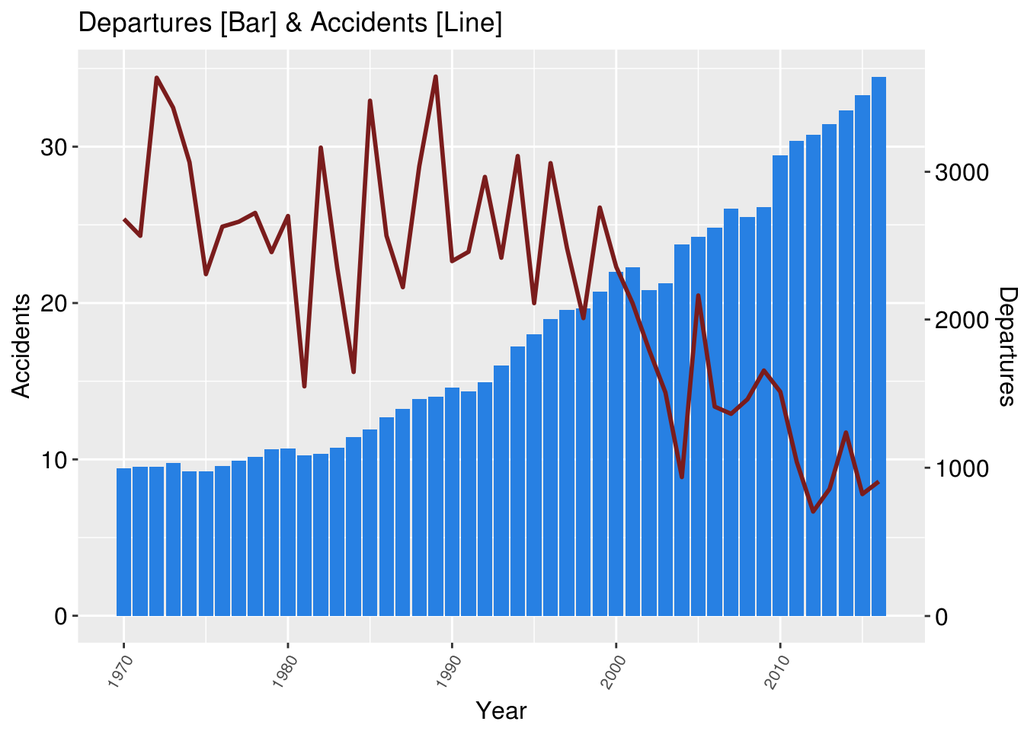

## Top Civil Operators’ Crashes & Fatalities

### Over Years

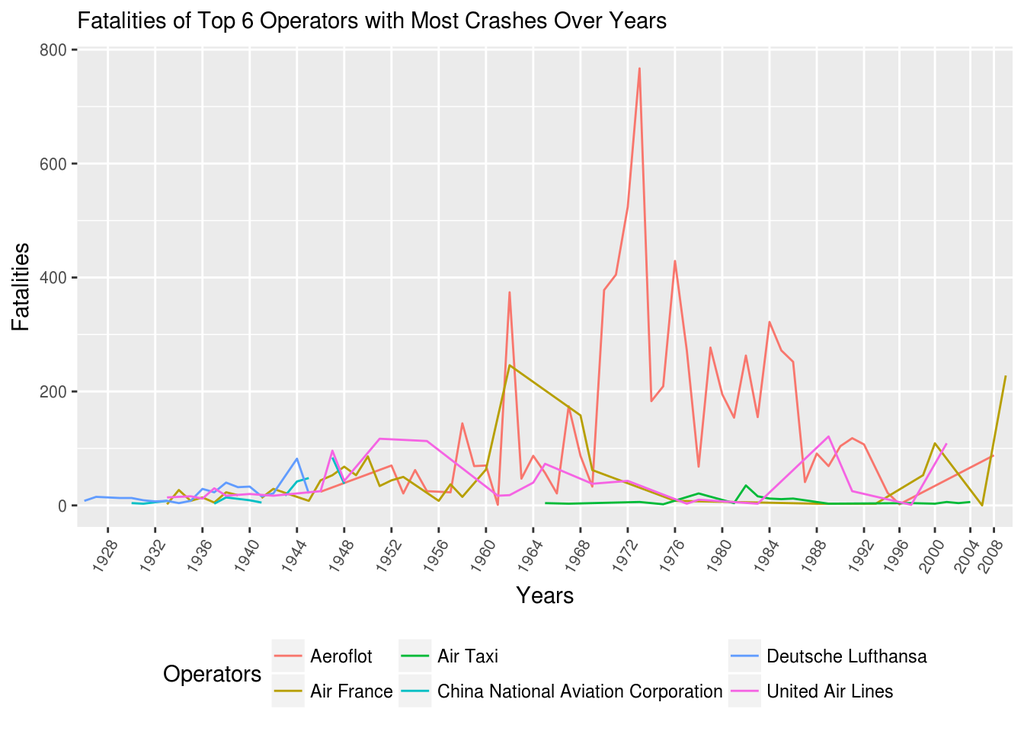

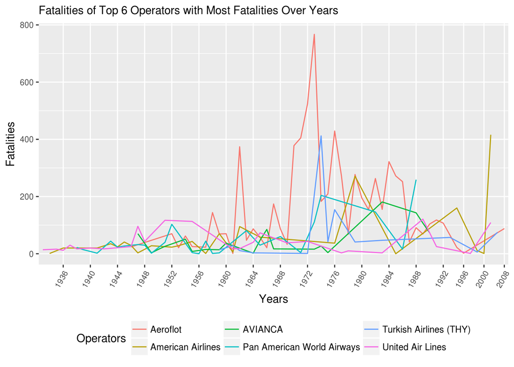

## Crash History of Turkish Airlines

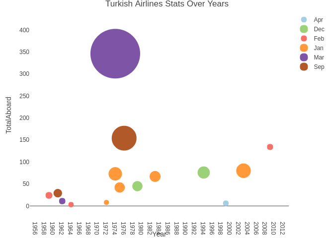

## Fatalities & Total Passengers

### Over Years

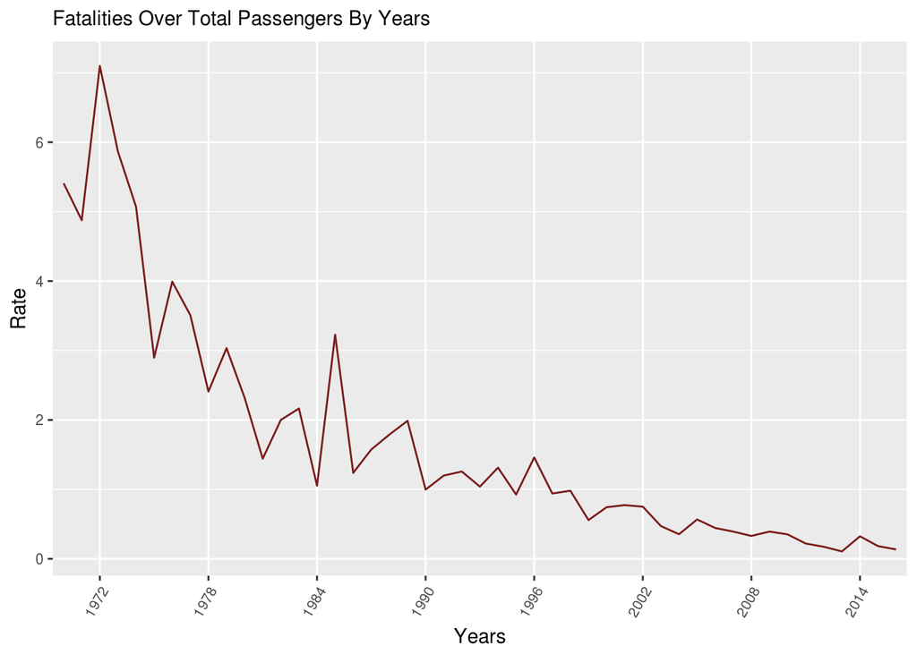

## Has Survival Rate Increased Over Time?

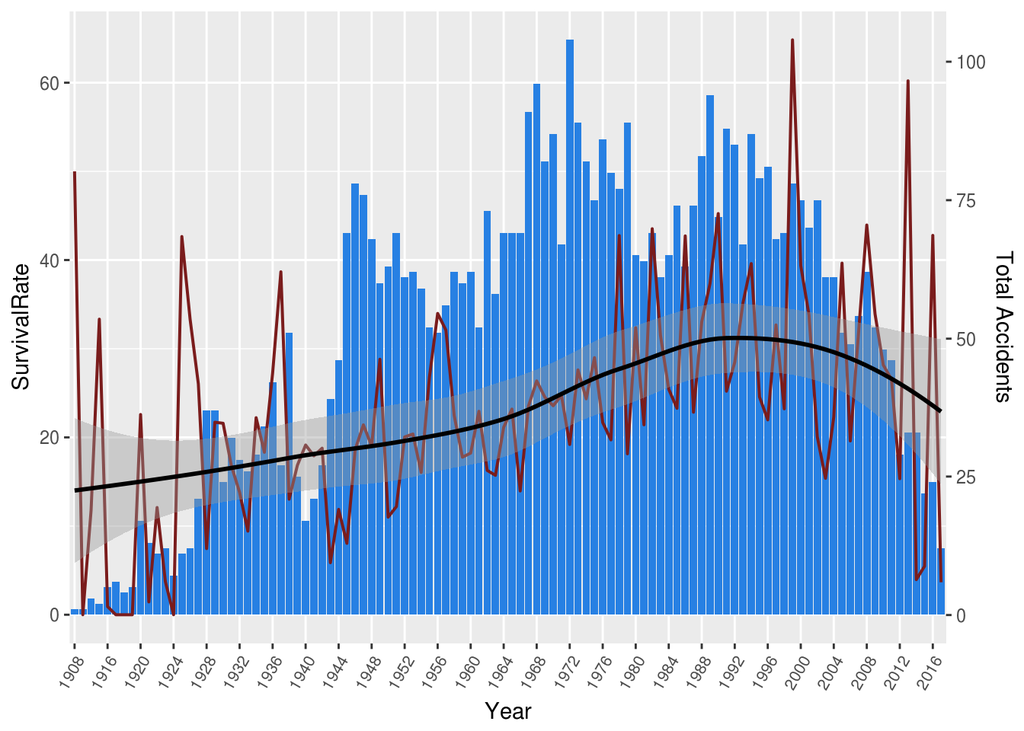

## Possible Causes of Crashes

### Word Cloud

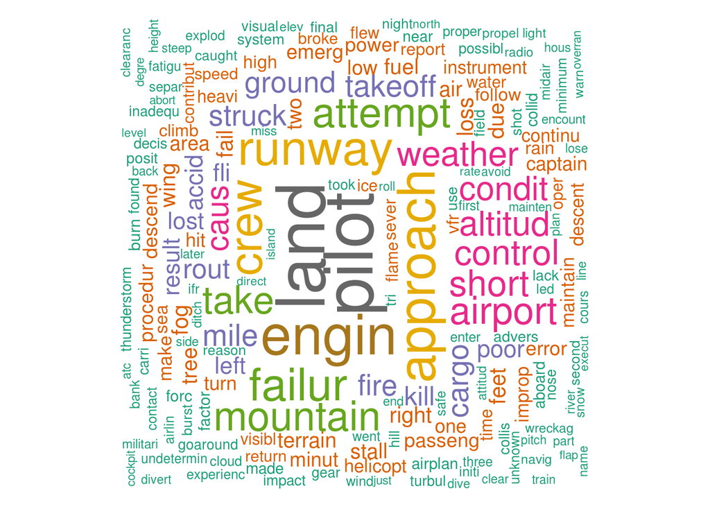

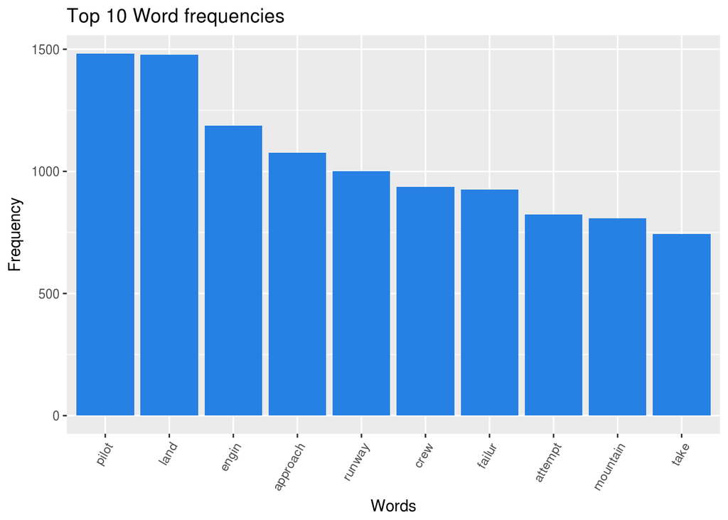

## Where do accidents occur?

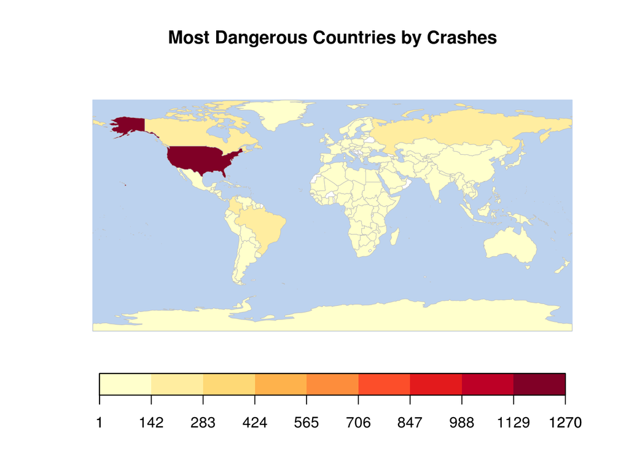

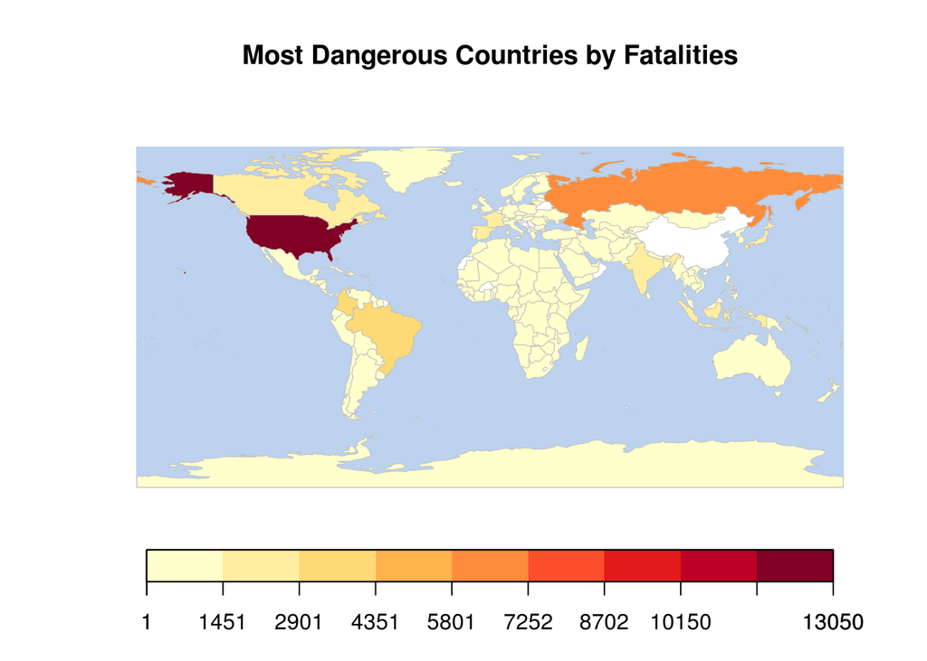

## Conclusion

[figure not shown]